# 데이터분석 비본 - numpy

다음 토픽을 다룹니다.:

- Numpy 기초
- Built-in methods and functions
- shape, length and type of Numpy arrays
- Reshape
- Minimum and maximum
- Mathematical Operations
- Indexing and slicing
- Selection

# NUMPY BASICS

- NumPy는 다차원 배열을 처리할 수 있는 선형대수학(Linear Algebra) 라이브러리입니다.
- 다음이 실행이 안되면 아나콘다프롬프트에서 conda install numpy 를 실행하여 설치합니다.

```python
[{'이름': '홍길동', '나이': 33, '연봉': 30000}, {'이름': '김나나', '나이': 23, '연봉': 60000}, {'이름': '해피', '나이': 40, '연봉': 70000}]
# 연봉순 정렬
# 순수 파이썬으로는 데이터 분석하기 힘들다.
# 일반적으로 실제 데이터는 행과 열로 되어 있음.

# 메모장, 엑셀을 예시로 설명 (테블러 데이터)
# 이름, 나이, 이메일, 연봉
# 홍길동, 20, happy@gmail.com, 40000


# 데이터 분석은 일반적으로 파일 또는 DB의 데이터를 불러와서 분석을 함.
```

```
[{'이름': '홍길동', '나이': 33, '연봉': 30000},
 {'이름': '김나나', '나이': 23, '연봉': 60000},
 {'이름': '해피', '나이': 40, '연봉': 70000}]
```

```python
# key: value, key: value
[{}, {}, {}]

# 3차원 데이터 -> 이미지 : 행렬이 3차원으로 되어 있음. RGB

# 컴퓨터는 계산을 하려면 모두 숫자로 변환, vector화한다.
# (3,4)      2차원
# (1,3,4)    3차원
# (3,4,5,6)  4차원
# (1,2,3,3,4,5 ...... 1024)  1024차원
# 유사도를 계산하려면, 숫자로 변환 해야함.
```

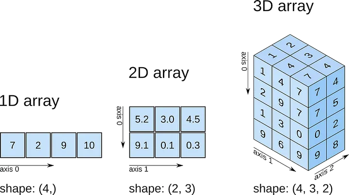

```python
(4,)
```

```
(4,)
```

```python
(2,3)
```

```
(2, 3)
```

```python
(2,3,4)
```

```
(2, 3, 4)
```

- numpy 설치

```python
%pip install numpy
```

```python
import numpy as np
np.__version__
```

```
'2.0.1'
```

- numpy 객체 생성

```python
# list -> numpy 객체
a = [1,2,3,4,5]
arr = np.array(a)
arr
```

```
array([1, 2, 3, 4, 5])
```

```python
# 튜플 -> numpy 객체
b = (1,2,3,4,5)
arr = np.array(b)
arr
```

```
array([1, 2, 3, 4, 5])
```

```python
arr
```

```
array([1, 2, 3, 4, 5])
```

```python
# 넘파이 1차원 배열 <- Vector(벡터)라고 함.
```

```python
a
```

```
[1, 2, 3, 4, 5]
```

```python
len(a)
```

```
5
```

```python
len(arr)
```

```
5
```

```python
# numpy 객체에 size 속성이 있음
arr.size
```

```
5
```

```python
# arr은 넘파이 객체
arr
```

```
array([1, 2, 3, 4, 5])
```

```python
type(a)
```

```
list
```

```python
type(arr)
```

```
numpy.ndarray
```

```python
# 넘파이 객체의 요소 데이터 타입
arr.dtype
```

```
dtype('int64')
```

```python
# 1 차원
arr.shape
```

```
(5,)
```

# 2차원 데이터 만들기

```python
a2d = [[1,2,3], [4,5,6], [7,8,9]]
a2d
```

```
[[1, 2, 3], [4, 5, 6], [7, 8, 9]]
```

```python
type(a2d)
```

```
list
```

```python
arr2d = np.array(a2d)
arr2d
```

```
array([[1, 2, 3],
       [4, 5, 6],
       [7, 8, 9]])
```

```python
arr2d.size
```

```
9
```

```python
arr2d.dtype
```

```
dtype('int64')
```

```python
type(arr2d)
```

```
numpy.ndarray
```

```python
arr2d.shape
```

```
(3, 3)
```

```python
arr2 = np.array([1, 2, 'aa'])
arr2
```

```
array(['1', '2', 'aa'], dtype='<U21')
```

### Save and Load data

```python
arr2d
```

```
array([[1, 2, 3],
       [4, 5, 6],
       [7, 8, 9]])
```

```python
# 파일로 저장하기
np.save('my_array', arr2d)
```

[확인하기] my_array.npy 파일이 폴더에 생겼는지 확인하세요.

```python
# 파일로 저장된것 불로오기
arr2d = np.load('my_array.npy')
arr2d
```

```
array([[1, 2, 3],
       [4, 5, 6],
       [7, 8, 9]])
```

# BUILT-IN METHODS AND FUNCTIONS

```python
np.zeros(4)
```

```
array([0., 0., 0., 0.])
```

```python
np.zeros((2,3,4))
```

```
array([[[0., 0., 0., 0.],
        [0., 0., 0., 0.],
        [0., 0., 0., 0.]],

       [[0., 0., 0., 0.],
        [0., 0., 0., 0.],
        [0., 0., 0., 0.]]])
```

```python
# 1차원
np.ones((7,))
```

```
array([1., 1., 1., 1., 1., 1., 1.])
```

```python
# 2차원
np.ones((4,7))
```

```
array([[1., 1., 1., 1., 1., 1., 1.],
       [1., 1., 1., 1., 1., 1., 1.],
       [1., 1., 1., 1., 1., 1., 1.],
       [1., 1., 1., 1., 1., 1., 1.]])
```

### 특정 값으로, 행렬 만들기

```python
# np.full(shape, 특정값)
np.full((7,), 5)
```

```
array([5, 5, 5, 5, 5, 5, 5])
```

```python
np.full((7,2), 5)
```

```
array([[5, 5],
       [5, 5],
       [5, 5],
       [5, 5],
       [5, 5],
       [5, 5],
       [5, 5]])
```

```python
np.full((4,2,3), 5)
```

```
array([[[5, 5, 5],
        [5, 5, 5]],

       [[5, 5, 5],
        [5, 5, 5]],

       [[5, 5, 5],
        [5, 5, 5]],

       [[5, 5, 5],
        [5, 5, 5]]])
```

### 정수의 배열을 얻고자 할때

```python
# [0, 1, 2, 3, 4, 5, 6, 6, 7, 8, 9]
list(range(10))
```

```
[0, 1, 2, 3, 4, 5, 6, 7, 8, 9]
```

```python
# numpy로 표현하기
np.arange(10)
```

```
array([0, 1, 2, 3, 4, 5, 6, 7, 8, 9])
```

```python
np.arange(5, 30+1)
```

```
array([ 5,  6,  7,  8,  9, 10, 11, 12, 13, 14, 15, 16, 17, 18, 19, 20, 21,
       22, 23, 24, 25, 26, 27, 28, 29, 30])
```

#### np.arange(start,stop,step)

```python
# np.arange(start, stop, step)
np.arange(1, 10, 2)
```

```
array([1, 3, 5, 7, 9])
```

### 정수 말고 실수를 얻고자 할때

```python
# lin -> liner : 실수 값
# np.linspace(start, end, 갯수)
np.linspace(0, 20, 15)
```

```
array([ 0.        ,  1.42857143,  2.85714286,  4.28571429,  5.71428571,
        7.14285714,  8.57142857, 10.        , 11.42857143, 12.85714286,
       14.28571429, 15.71428571, 17.14285714, 18.57142857, 20.        ])
```

```python
# 1차원 배열 = 벡터 (Vector)
# 2차원 배열 = 행렬 (Matrix)
```

### 이렇게 1차원 배열을 얻은 후, 우리는 이것을 가지고 여러차원으로 만들 수 있다.

### reshape 을 이용

[figure not shown]

```python
# reshape
arr = np.arange(1,21+1)
```

```python
arr2d = arr.reshape(3, 7)
arr2d
```

```
array([[ 1,  2,  3,  4,  5,  6,  7],
       [ 8,  9, 10, 11, 12, 13, 14],
       [15, 16, 17, 18, 19, 20, 21]])
```

```python
arr2d.shape
```

```
(3, 7)
```

```python
arr2d = arr.reshape(7, 3)
arr2d
```

```
array([[ 1,  2,  3],
       [ 4,  5,  6],
       [ 7,  8,  9],
       [10, 11, 12],
       [13, 14, 15],
       [16, 17, 18],
       [19, 20, 21]])
```

```python
arr2d.shape
```

```
(7, 3)
```

```python
arr1d = arr2d.reshape(21)
arr1d
```

```
array([ 1,  2,  3,  4,  5,  6,  7,  8,  9, 10, 11, 12, 13, 14, 15, 16, 17,
       18, 19, 20, 21])
```

```python
arr2d =arr1d.reshape(-1, 3)
arr2d
```

```
array([[ 1,  2,  3],
       [ 4,  5,  6],
       [ 7,  8,  9],
       [10, 11, 12],
       [13, 14, 15],
       [16, 17, 18],
       [19, 20, 21]])
```

```python
arr2d.max()
```

```
np.int64(21)
```

```python
arr2d.min()
```

```
np.int64(1)
```

```python
arr2d.sum()
```

```
np.int64(231)
```

```python
arr
```

```
array([ 1,  2,  3,  4,  5,  6,  7,  8,  9, 10, 11, 12, 13, 14, 15, 16, 17,
       18, 19, 20, 21])
```

```python
arr.sum()
```

```
np.int64(231)
```

```python
# 평균
arr.mean()
```

```
np.float64(11.0)
```

```python
# 표준편차 :  평균으로부터 데이터가 얼마나 떨어져있는가?를 의미함.
print(arr.std())
```

```
6.0553007081949835
```

```python
arr.var()
```

```
np.float64(36.666666666666664)
```

### 여러단계를 거치지 말고, 한번에 원하는 다차원 배열로 만들 수 있다.

```python
# 5부터 19까지
a = np.arange(5, 20)
a.size
```

```
15
```

```python
a.reshape(3,5)
```

```
array([[ 5,  6,  7,  8,  9],
       [10, 11, 12, 13, 14],
       [15, 16, 17, 18, 19]])
```

```python
# 5~19까지의 정수로 (3,5) 행렬을 만들고 싶다.
# chain 형식으로 표현
np.arange(5, 20).reshape(3, 5)
```

```
array([[ 5,  6,  7,  8,  9],
       [10, 11, 12, 13, 14],
       [15, 16, 17, 18, 19]])
```

### 랜덤값으로 채워진 배열을 만들 수 있다.

```python
import random
```

```python
random.random()
```

```
0.8659848145295426
```

```python
# 파이썬의 기본 랜덤 라이브러리는 다차원 배열이 안됨
```

```python
# 랜덤으로 5개의 숫자를 만들고싶음.
np.random.random(5)
```

```
array([0.54859361, 0.79049519, 0.34569744, 0.57868059, 0.29015141])
```

```python
np.random.random((5,))
```

```
array([0.60866181, 0.61645142, 0.66160482, 0.5268156 , 0.04680093])
```

- 랜덤 seed

```python
# 0~1사이의 실수로 난수 발생
np.random.random((3,5))
```

```
array([[0.41729469, 0.51028363, 0.74540125, 0.84550823, 0.65973943],
       [0.98869833, 0.25276928, 0.55008161, 0.93191697, 0.11378677],
       [0.58257265, 0.62616908, 0.5994077 , 0.54851441, 0.42742218]])
```

```python
random.seed(4)
random.random()
```

```
0.23604808973743452
```

```python
# random.seed(3)
# 랜덤으로 뽑는 숫자가 나오는 패턴을 일치시키는 방법
# 첫번째 실행에 나온숫자, 두번째 실행에 나온숫자, ... => 패턴
# 하나의 셀에만 적용
```

```python
random.random()
```

```
0.1031660342307158
```

```python
# numpy의 seed 고정 방법, 순서대로 실행하는게 중요함.
np.random.seed(3)
```

```python
np.random.random((3,5))
```

```
array([[0.5507979 , 0.70814782, 0.29090474, 0.51082761, 0.89294695],
       [0.89629309, 0.12558531, 0.20724288, 0.0514672 , 0.44080984],
       [0.02987621, 0.45683322, 0.64914405, 0.27848728, 0.6762549 ]])
```

```python
np.random.random((3,5))
```

```
array([[0.59086282, 0.02398188, 0.55885409, 0.25925245, 0.4151012 ],
       [0.28352508, 0.69313792, 0.44045372, 0.15686774, 0.54464902],
       [0.78031476, 0.30636353, 0.22195788, 0.38797126, 0.93638365]])
```

### np.random.randint(start, stop, size = shape)

### 시작값과 끝값을 줄 수 있다.

```python
np.random.seed(9)
```

```python
# np.rnadom.seed(9) 실행하고, 한번만 적용
np.random.randint(1, 45, (7,))
```

```
array([29, 23,  2, 23, 41, 28, 34], dtype=int32)
```

```python
np.random.randint(1, 45, (3,4))
```

```
array([[30, 29,  1, 25],
       [11, 30, 43, 13],
       [19, 23,  2, 36]], dtype=int32)
```

```python
# 1~9+1
X = np.random.randint(1, 100, (3,4))
```

```python
# 데이터 전체에서 최대값, 최소값, 전체합, 전체평균, 표준편차, 중앙값을 구하세요
```

```python
X.max()
```

```
np.int32(91)
```

```python
X.min()
```

```
np.int32(3)
```

```python
X.mean()
```

```
np.float64(43.916666666666664)
```

```python
X.std()
```

```
np.float64(26.79383739262113)
```

```python
X.var()
```

```
np.float64(717.9097222222222)
```

```python
a = np.array([3,4,5,6,7,8,9,10])
sorted(a.tolist())
```

```
[3, 4, 5, 6, 7, 8, 9, 10]
```

```python
type(a)
```

```
numpy.ndarray
```

```python
# 중앙값 => 데이터를 오름차순으로 정렬한 후, 중간에 있는 값
# 넘파이 객체에는 median이 없음
# 중앙 값이 두개인 경우는 두 값의 평균을 구함.

np.median(a)
```

```
np.float64(6.5)
```

```python
np.random.seed(3)
X = np.random.randint(1, 100, (4,5))
X
```

```
array([[25,  4, 57, 73,  1],
       [22, 20, 75, 42, 11],
       [22, 39, 97, 21, 45],
       [94, 40, 15, 27, 82]], dtype=int32)
```

- axis = 0 : 행 인덱스가 증가하는 방향
- axis = 1 : 열 인덱스가 증가하는 방향

```python
# 각 열별 최대 값을 구하고 싶다.
# [94, 40, 97, 73, 82]
# 가장 큰 값을 구해야 하는 경우

X.max(axis=0)
```

```
array([94, 40, 97, 73, 82], dtype=int32)
```

```python
# 각 행별 최대 값을 구하고 싶다.
# [73, 75, 97, 94]
# 가장 큰 값을 구해야 하는 경우

X.max(axis=1)
```

```
array([73, 75, 97, 94], dtype=int32)
```

```python
X
```

```
array([[25,  4, 57, 73,  1],
       [22, 20, 75, 42, 11],
       [22, 39, 97, 21, 45],
       [94, 40, 15, 27, 82]], dtype=int32)
```

- 비교

```python
# 원하는 데이터의 갯수를 구하는 방법
# X에서 70보다 큰 데이터는 몇개?
X>70
```

```
array([[False, False, False,  True, False],
       [False, False,  True, False, False],
       [False, False,  True, False, False],
       [ True, False, False, False,  True]])
```

```python
(X>70).sum()
```

```
np.int64(5)
```

```python
# X에서 70보다 큰 데이터들만 가져와
```

```python
X[X > 70]
```

```
array([73, 75, 97, 94, 82], dtype=int32)
```

```python
X[X > 70].size
```

```
5
```

# [실습]

- 4 x 4 ndarray 만드세요.
- 단, 2 에서 32 까지의 순차적 짝수로 채워지도록 하세요.

```python
import numpy as np
X = np.arange(2,32+1, 2).reshape(4,4)
```

```python
X
```

```
array([[ 2,  4,  6,  8],
       [10, 12, 14, 16],
       [18, 20, 22, 24],
       [26, 28, 30, 32]])
```

# SHAPE, LENGTH AND TYPE OF NUMPY ARRAYS

```python
X
```

```
array([[ 2,  4,  6,  8],
       [10, 12, 14, 16],
       [18, 20, 22, 24],
       [26, 28, 30, 32]])
```

```python
X.shape
```

```
(4, 4)
```

```python
X.size
```

```
16
```

```python
X.dtype
```

```
dtype('int64')
```

# MAX AND MIN VALUES AND THEIR INDEX

```python
X.max()
```

```
np.int64(32)
```

```python
X.min()
```

```
np.int64(2)
```

```python
X
```

```
array([[ 2,  4,  6,  8],
       [10, 12, 14, 16],
       [18, 20, 22, 24],
       [26, 28, 30, 32]])
```

```python
np.random.seed(3)
X = np.random.randint(1, 100, (4,5))
X
```

```
array([[25,  4, 57, 73,  1],
       [22, 20, 75, 42, 11],
       [22, 39, 97, 21, 45],
       [94, 40, 15, 27, 82]], dtype=int32)
```

```python
# 전체 최대 값이 있는 곳의 위치는?
X.max(axis=0)
```

```
array([94, 40, 97, 73, 82], dtype=int32)
```

```python
X.argmax()
```

```
np.int64(12)
```

```python
X.argmin()
```

```
np.int64(4)
```

```python
X
```

```
array([[25,  4, 57, 73,  1],
       [22, 20, 75, 42, 11],
       [22, 39, 97, 21, 45],
       [94, 40, 15, 27, 82]], dtype=int32)
```

```python
# 행별 최대값의 위치? 행이 증가하는 방향
X.argmax(axis=0)
```

```
array([3, 3, 2, 0, 3])
```

```python
# 열별 최대값의 위치? 열이 증가하는 방향
X.argmax(axis=1)
```

```
array([3, 2, 2, 0])
```

# Accessing Elements Into ndarrays

```python
x = np.random.randint(1,100,7)
x
```

```
array([91, 23, 67,  3, 64, 61,  2], dtype=int32)
```

```python
x[2]
```

```
np.int32(67)
```

```python
x[-1]
```

```
np.int32(2)
```

### 다차원배열의 인덱스 접근

```python
X
```

```
array([[25,  4, 57, 73,  1],
       [22, 20, 75, 42, 11],
       [22, 39, 97, 21, 45],
       [94, 40, 15, 27, 82]], dtype=int32)
```

```python
# 2행 3열 위치 데이터를 가져오시오.
X[1][2]
```

```
np.int32(75)
```

```python
# numpy에서는 다음과 같이 표현할 수 있음
X[1, 2]
```

```
np.int32(75)
```

```python
X[3,4]
```

```
np.int32(82)
```

# Slicing - 잘라서 가져오기

### 1. ndarray[start:end]

### 2. ndarray[start:]

### 3. ndarray[:end]

```python
X
```

```
array([[25,  4, 57, 73,  1],
       [22, 20, 75, 42, 11],
       [22, 39, 97, 21, 45],
       [94, 40, 15, 27, 82]], dtype=int32)
```

```python
# 슬라이싱 데이터 : [25,  4, 57]
X[0, :3]
```

```
array([25,  4, 57], dtype=int32)
```

```python
# [[22, 39, 97],
#  [94, 40, 15]]

X[2: , :2+1]
```

```
array([[22, 39, 97],
       [94, 40, 15]], dtype=int32)
```

```python
# 데이터 억세스 기호는 대괄호 [, ] => 콤마의 왼쪽은 행자리, 오른쪽은 열자리.
# 행자리도 : 을 사용,
# 열자리도 : 을 사용할 수 있음
```

```python
X
```

```
array([[25,  4, 57, 73,  1],
       [22, 20, 75, 42, 11],
       [22, 39, 97, 21, 45],
       [94, 40, 15, 27, 82]], dtype=int32)
```

```python
# 20, 75
# 39, 97
# 40, 15
# 값 가져오기
X[1:3+1, 1:2+1]
```

```
array([[20, 75],
       [39, 97],
       [40, 15]], dtype=int32)
```

```python
X
```

```
array([[25,  4, 57, 73,  1],
       [22, 20, 75, 42, 11],
       [22, 39, 97, 21, 45],
       [94, 40, 15, 27, 82]], dtype=int32)
```

```python
# 57, 73, 1
# 75, 42, 11

X[:1+1, 2:]
```

```
array([[57, 73,  1],
       [75, 42, 11]], dtype=int32)
```

# 실습

- X = 5 x 5 ndarray 를 만드세요.정수 1 부터 25 까지 순차적으로 들어있습니다.
- Y = Boolean indexing 을 이용해서 홀수만 뽑아서 배열로 만듭니다.

```python
X = np.arange(1, 26).reshape(-1,5)
X
```

```
array([[ 1,  2,  3,  4,  5],
       [ 6,  7,  8,  9, 10],
       [11, 12, 13, 14, 15],
       [16, 17, 18, 19, 20],
       [21, 22, 23, 24, 25]])
```

```python
Y = X[X % 2 == 1]
Y
```

```
array([ 1,  3,  5,  7,  9, 11, 13, 15, 17, 19, 21, 23, 25])
```

# Arithmetic operations and Broadcasting

### 1차원 배열 연산

```python
x
```

```
array([91, 23, 67,  3, 64, 61,  2], dtype=int32)
```

```python
#  학생들 수학점수가 있다.
score_list = [77, 46, 55, 99, 87, 81]
score_list
```

```
[77, 46, 55, 99, 87, 81]
```

```python
# 각 학생의 점수를 7점씩 빼야 한다.
new_score_list =[]
for score in score_list:
    new_score_list.append(score - 7)
new_score_list
```

```
[70, 39, 48, 92, 80, 74]
```

```python
# numpy 방법, 브로드캐스팅
np.array(score_list) - 7
```

```
array([70, 39, 48, 92, 80, 74])
```

```python
x
```

```
array([91, 23, 67,  3, 64, 61,  2], dtype=int32)
```

```python
x-10
```

```
array([81, 13, 57, -7, 54, 51, -8], dtype=int32)
```

```python
x // 2
```

```
array([45, 11, 33,  1, 32, 30,  1], dtype=int32)
```

### 2차원 배열 연산

```python
X
```

```
array([[ 1,  2,  3,  4,  5],
       [ 6,  7,  8,  9, 10],
       [11, 12, 13, 14, 15],
       [16, 17, 18, 19, 20],
       [21, 22, 23, 24, 25]])
```

```python
X*2
```

```
array([[ 2,  4,  6,  8, 10],
       [12, 14, 16, 18, 20],
       [22, 24, 26, 28, 30],
       [32, 34, 36, 38, 40],
       [42, 44, 46, 48, 50]])
```

```python
X+10
```

```
array([[11, 12, 13, 14, 15],
       [16, 17, 18, 19, 20],
       [21, 22, 23, 24, 25],
       [26, 27, 28, 29, 30],
       [31, 32, 33, 34, 35]])
```

```python
X // 2
```

```
array([[ 0,  1,  1,  2,  2],
       [ 3,  3,  4,  4,  5],
       [ 5,  6,  6,  7,  7],
       [ 8,  8,  9,  9, 10],
       [10, 11, 11, 12, 12]])
```

### 각 요소마다 연산이 수행됨, 브로드캐스팅

```python
# 학생들 점수가 있습니다. [56, 75, 88, 92, 66]
# 이 학생들의 점수가 잘못 되어서, -5점씩 한 점수로 바꿔야 합니다.
```